# 红酒中化学成分对酒质量的影响分析

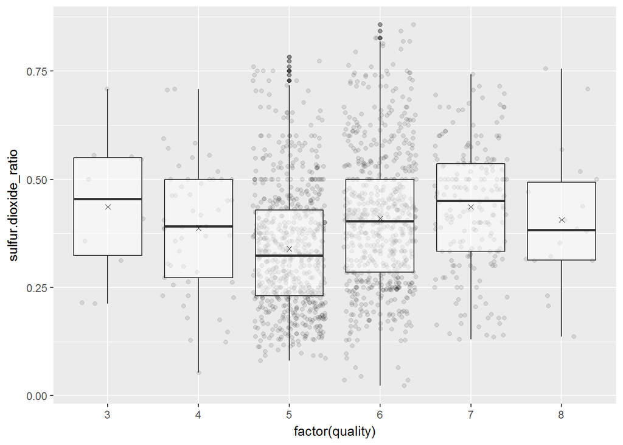

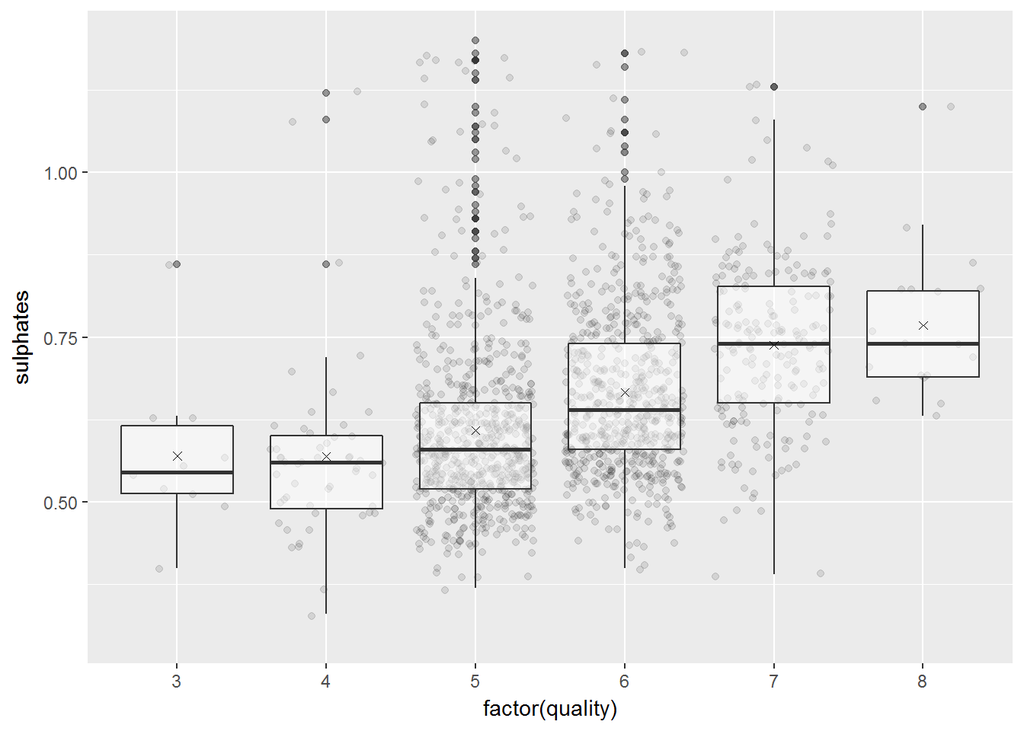

```
##
## Calls:
## m6: lm(formula = I(quality) ~ I(free.sulfur.dioxide), data = wqr)
## m7: lm(formula = I(quality) ~ I(total.sulfur.dioxide), data = wqr)
## m8: lm(formula = I(quality) ~ I(sulfur.dioxide_ratio), data = wqr)
## m9: lm(formula = I(quality) ~ I(sulphates), data = wqr)
##
## ===================================================================================
##                                 m6            m7            m8            m9
## -----------------------------------------------------------------------------------
##   (Intercept)                  5.698***      5.847***      5.249***      4.848***
##                               (0.037)       (0.034)       (0.053)       (0.078)
##   I(free.sulfur.dioxide)      -0.004*
##                               (0.002)
##   I(total.sulfur.dioxide)                   -0.005***
##                                             (0.001)
##   I(sulfur.dioxide_ratio)                                  1.013***
##                                                           (0.128)
##   I(sulphates)                                                           1.198***
##                                                                         (0.115)
## -----------------------------------------------------------------------------------
##   R-squared                    0.003         0.034         0.038         0.063
##   adj. R-squared               0.002         0.034         0.037         0.063
##   sigma                        0.807         0.794         0.792         0.782
##   F                            4.109        56.658        62.531       107.740
##   p                            0.043         0.000         0.000         0.000
##   Log-likelihood           -1924.580     -1898.761     -1895.927     -1874.438
##   Deviance                  1039.491      1006.458      1002.896       976.300
##   AIC                       3855.160      3803.523      3797.854      3754.876
##   BIC                       3871.292      3819.654      3813.985      3771.008
##   N                         1599          1599          1599          1599
## ===================================================================================
```

通过查阅资料我得到游离二氧化硫和总二氧化硫的比率与酒的质量具有相关性，因此我绘制了它们的散点图，并在散点图上画出两者的箱线图，通过箱线图中的均值点，我们可以得出的结论：两者的比率与红酒质量成正相关性,而总二氧化硫则与红酒质量负相关，所以我得出红酒中的二氧化硫在游离状态时，红酒的质量更高。同时，我还绘制了硫酸盐与质量的散点图，硫酸盐与红酒质量正相关。

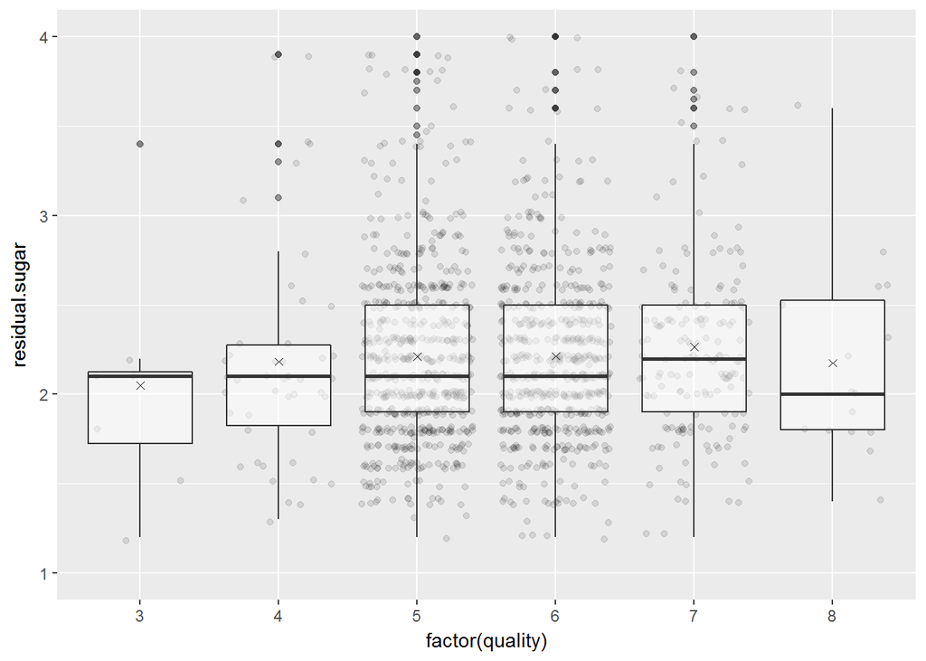

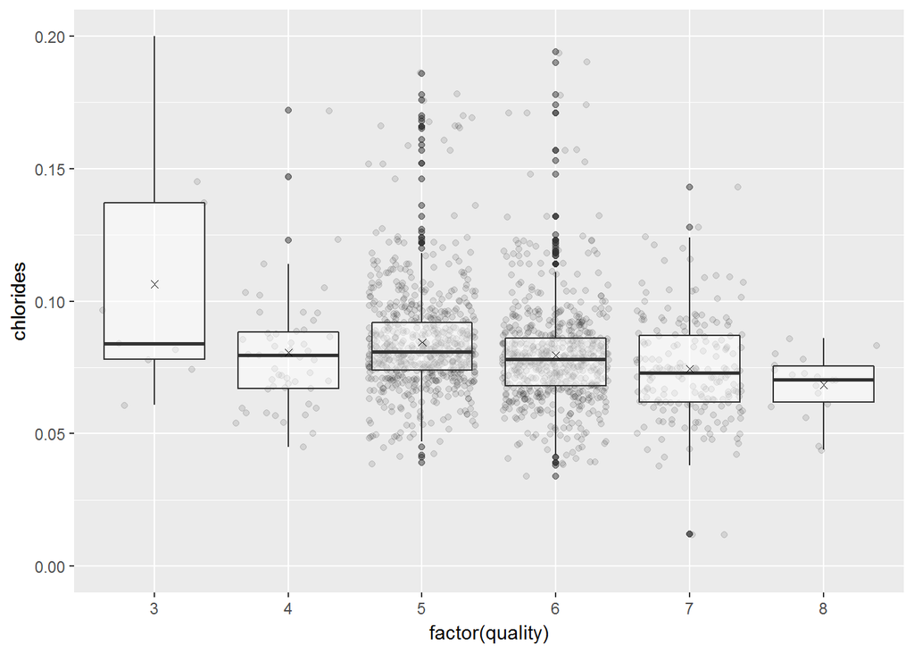

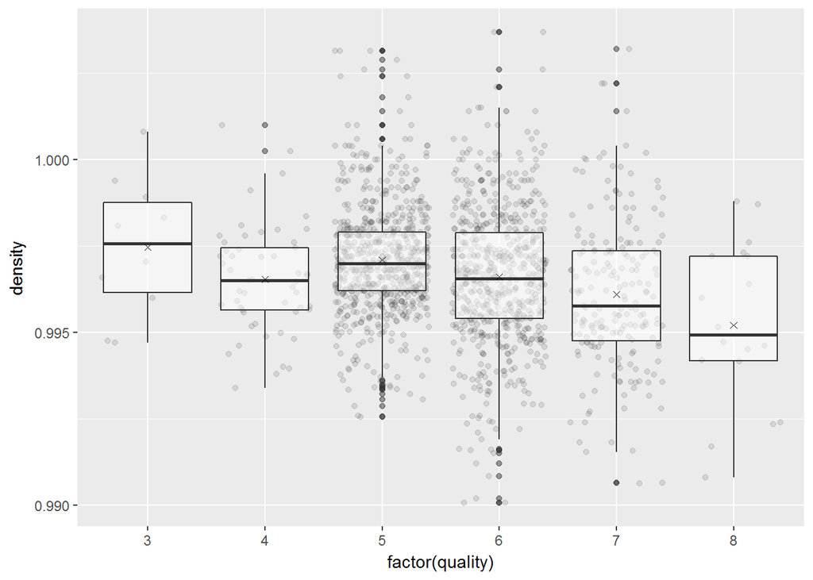

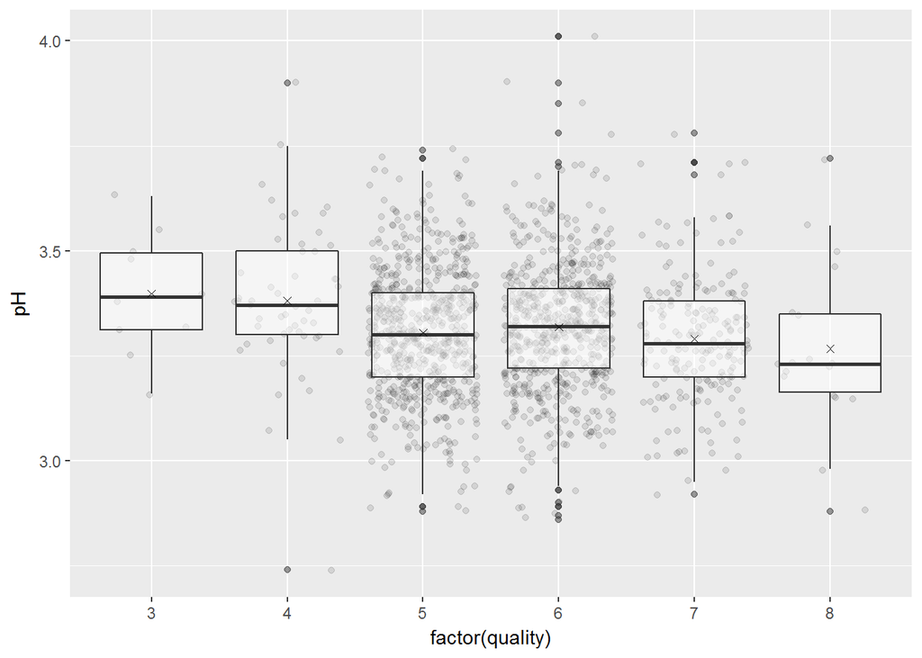

```
##
## Calls:
## m10: lm(formula = I(quality) ~ I(residual.sugar), data = wqr)
## m11: lm(formula = I(quality) ~ I(chlorides), data = wqr)
## m12: lm(formula = I(quality) ~ I(density), data = wqr)
## m13: lm(formula = I(quality) ~ I(pH), data = wqr)
##
## =============================================================================
##                          m10           m11           m12           m13
## -----------------------------------------------------------------------------
##   (Intercept)            5.616***      5.829***     80.239***      6.636***
##                         (0.042)       (0.042)      (10.508)       (0.433)
##   I(residual.sugar)      0.008
##                         (0.014)
##   I(chlorides)                        -2.212***
##                                       (0.426)
##   I(density)                                       -74.846***
##                                                    (10.542)
##   I(pH)                                                           -0.302*
##                                                                   (0.131)
## -----------------------------------------------------------------------------
##   R-squared              0.000         0.017         0.031         0.003
##   adj. R-squared        -0.000         0.016         0.030         0.003
##   sigma                  0.808         0.801         0.795         0.806
##   F                      0.301        26.986        50.405         5.340
##   p                      0.583         0.000         0.000         0.021
##   Log-likelihood     -1926.484     -1913.237     -1901.790     -1923.965
##   Deviance            1041.969      1024.848      1010.278      1038.692
##   AIC                 3858.967      3832.475      3809.580      3853.930
##   BIC                 3875.098      3848.606      3825.712      3870.062
##   N                   1599          1599          1599          1599
## =============================================================================
```

通过上面的图片我可以得到PH和残糖与酒的质量基本相关性不大，而密度和氯化物则与酒的质量呈现负相关性。

# 两个变量分析：

### 谈谈你在调查中观察到的一些关系。在数据集中，你感兴趣的特征是如何随着其他特征变化的?

我观察到红酒的质量与酒中的各项元素都有一定的关系，因此通过一些化学指标对红酒质量进行判断是一件非常困难的事情，但是，红酒质量与某些元素还是呈现了较强的相关性。其中，质量与酒精度、柠檬酸含量、硫酸盐含量以及创建的二氧化硫比率呈现正相关性，而红酒质量与挥发性酸、氯化物含量、密度以及PH值呈现负相关性。

### 你有没有观察到其他特征之间的有趣关系(而不是兴趣的主要特征)?

我还发现固定酸、挥发性酸和柠檬酸之间呈现强相关性。PH值与固定酸、柠檬酸和总酸之间有较强的负相关性。

### 你发现的最强的关系是什么?

我发现总酸与固定酸的关系最强，其次为总酸与PH值之间的关系。

# 多变量部分

由于在两个变量分析时，我们得到红酒质量与很多的元素都具有相关性，因此在这个模块我选择了几个相关性较大的元素来进行多个变量的分析。 首先我把与红酒质量相关性最强的酒精度和挥发性酸进行多变量分析，得到的散点图如下：

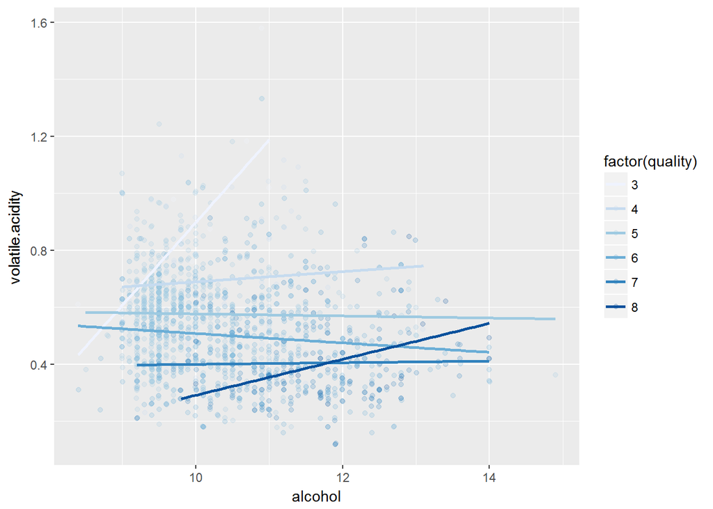

```
##
## Calls:
## m14: lm(formula = I(quality) ~ I(alcohol) + volatile.acidity, data = wqr)
##
## ==================================
##   (Intercept)           3.095***
##                        (0.184)
##   I(alcohol)            0.314***
##                        (0.016)
##   volatile.acidity     -1.384***
##                        (0.095)
## ----------------------------------
##   R-squared             0.317
##   adj. R-squared        0.316
##   sigma                 0.668
##   F                   370.379
##   p                     0.000
##   Log-likelihood    -1621.814
##   Deviance            711.796
##   AIC                3251.628
##   BIC                3273.136
##   N                  1599
## ==================================
```

由上图我们可以看到，当酒精浓度比较低时，不管挥发性酸如何变化，红酒的质量都不高；当挥发性酸比较高时，不管酒精浓度如何变化，红酒质量也不会高。只有在两者都在比较好的区间内，质量才会比较好。

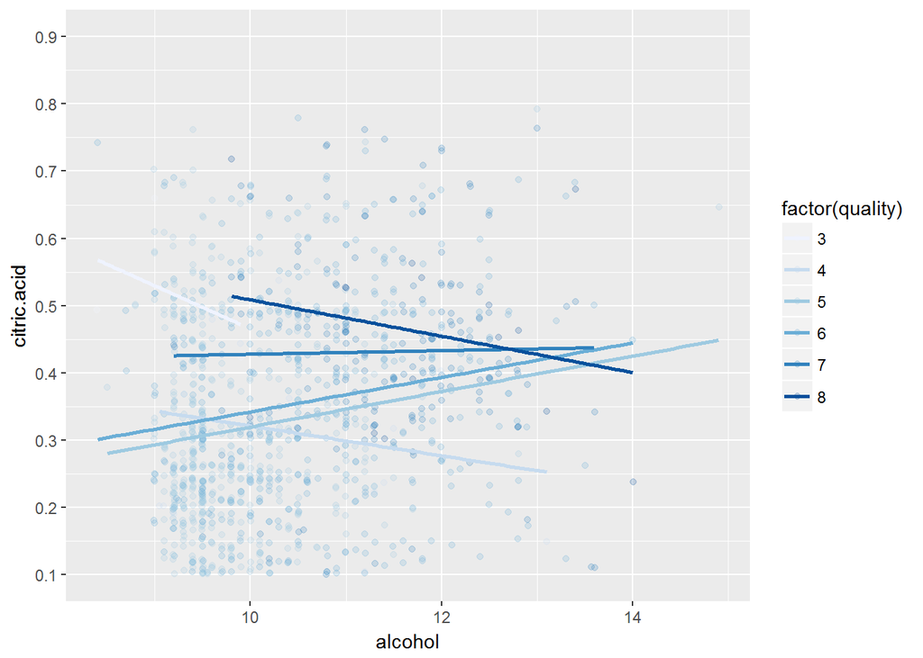

由上图我们可以看到，柠檬酸的含量对酒质量的影响要弱于酒精度，但是由图中还是可以看出在柠檬酸含量低时，即便有些酒的酒精度高，但是酒的质量并不高；而柠檬酸含量高时，酒的质量要优于柠檬酸含量低的红酒。

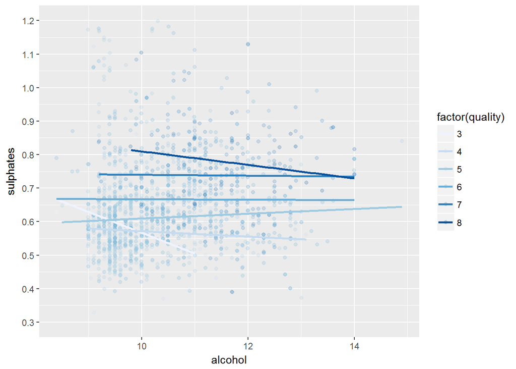

由上图我们可以看到，硫酸盐对红酒质量的影响基本和柠檬酸类似。虽然硫酸盐与红酒质量呈现一定的正相关趋势，但仍然不如酒精度对质量的影响。

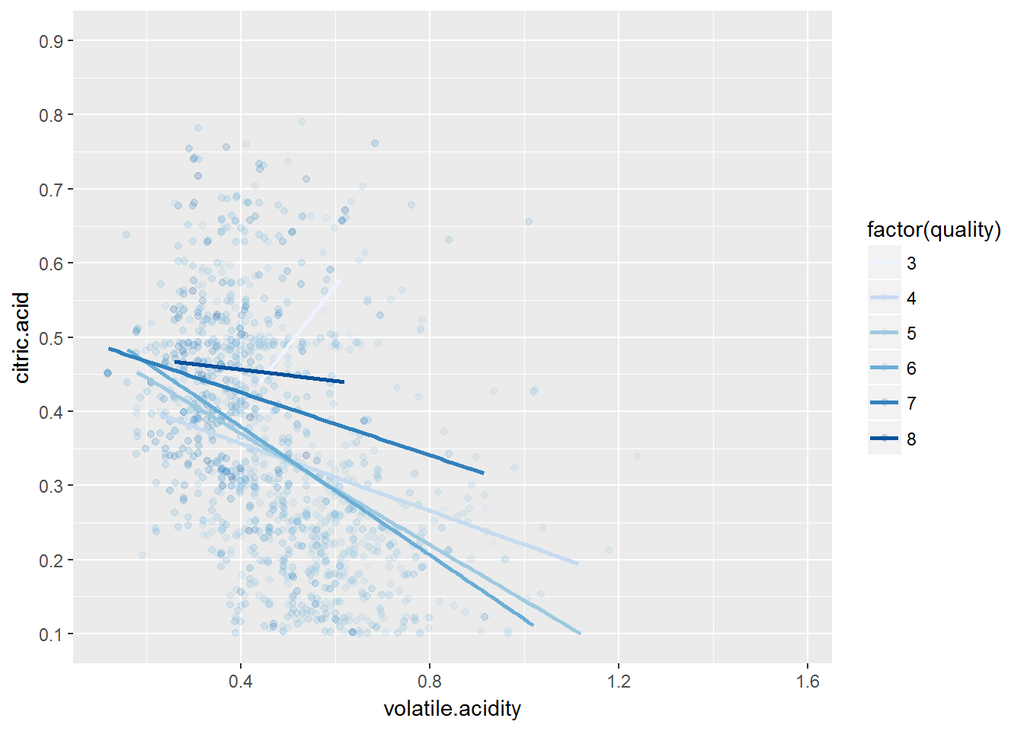

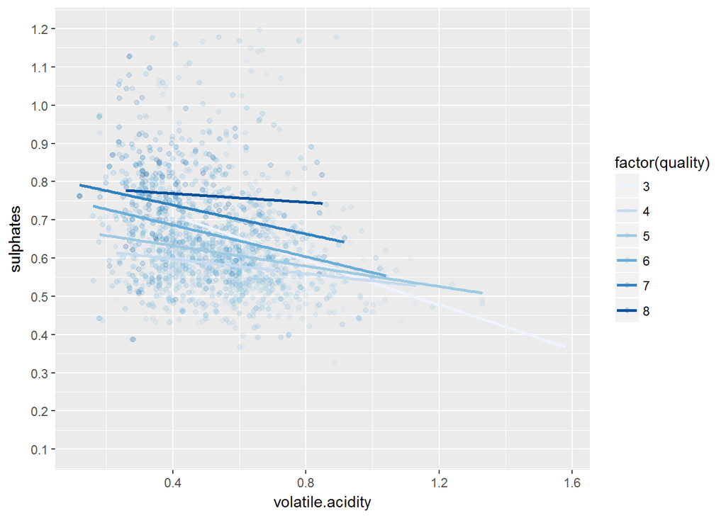

由上面的两个图片我们可以看到，硫酸盐和柠檬酸对红酒质量的影响虽然存在但仍然不如挥发性酸对红酒质量的影响。结合之前的结论，我得出对于红酒的质量最主要的两个影响因素就是酒精度和挥发性酸的含量，当这两者的含量较高或较低时，红酒质量主要由这两者影响；当这两者的含量居中时，其他因素才会对红酒质量产生明显的影响。

# 多变量分析

### 谈谈你在调查中观察到的一些关系。是否有一些特征在你关注的兴趣方面加强了彼此? 特征之间有什么有趣或令人惊讶的相互作用吗?

在多变量分析时，在加入其他的因素之后，并没有加强质量与酒精度和挥发性酸的关系。因此经过多变量分析，可以得出，红酒质量与酒精度和挥发性酸的关系最为密切。

# 最后的图和总结

### 图一

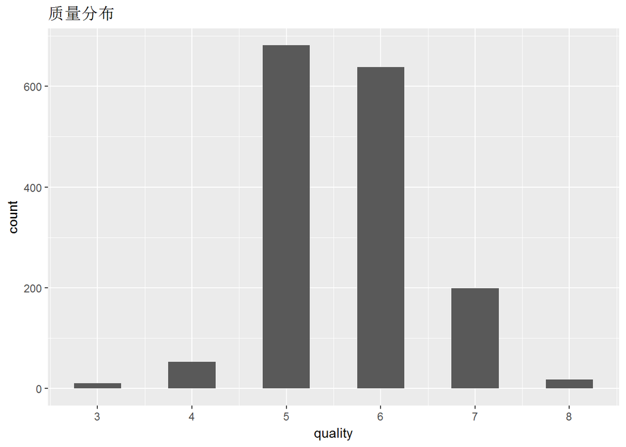

### 描述一

红酒的质量分数在0分（非常差）和10分（非常好）之间。本数据集中的红酒质量评分在3分~8分，其中绝大多数的评分为5分和6分，极好的和极差的葡萄酒的样本都是少数。

### 图二

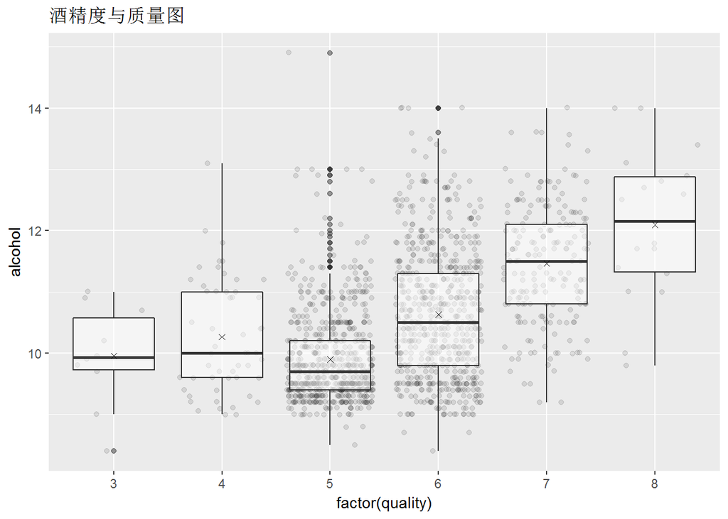

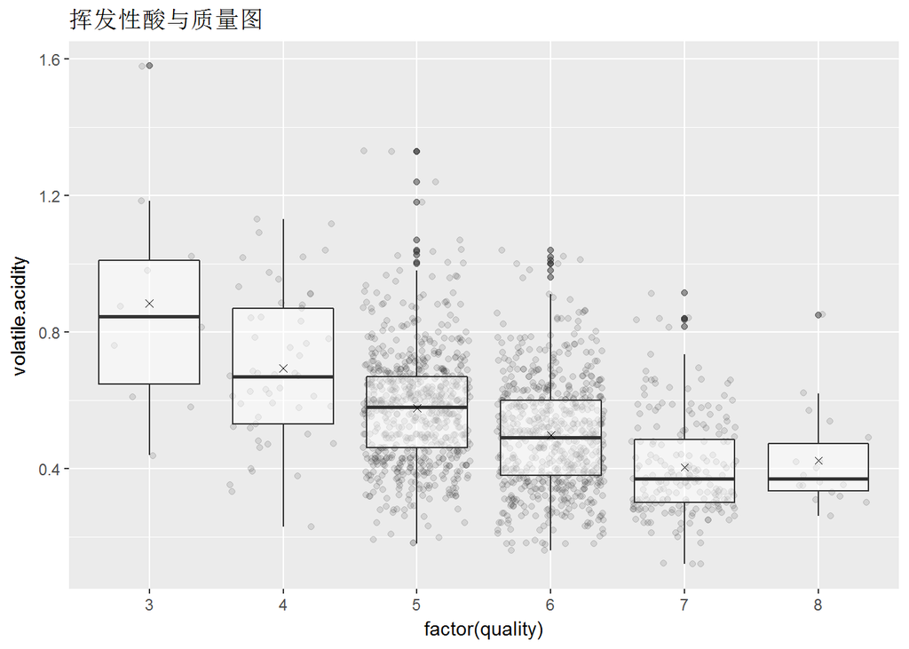

### 描述二

由图二的两幅图我得出红酒质量与酒精度呈现正相关性，酒精度越高，酒的品质越好。挥发性酸与酒的质量成明显的负相关性，挥发性酸的值越大，酒的质量越差。

### 图三

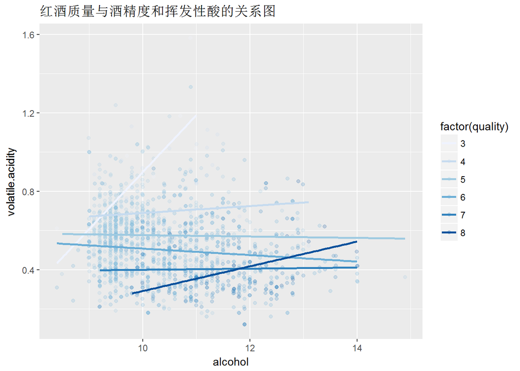

# 反思

[output not shown]